# Online Supplement 1: Visualizing Indices

- Show All Code
- Hide All Code
- View Source

For the Manuscript: Identifying Careless Responding in Ecological Momentary Assessment: Inconsistent Signals from Different Detection Methods in the WARN-D Data

Author

Affiliation

Björn S. Siepe

University of Marburg

Published

February 13, 2026

# 1 Background

In this document, we visualize and analyze all indices that were computed in `01_calculate_indices.qmd` *without* the reaction time (RT) indices.

We first load all relevant packages:

```r
if(!require(pacman))
  install.packages("pacman")
pacman::p_load(
  "here",
  "ggplot2",
  "rrcov",
  "Hmisc",
  "sysfonts",
  "showtext",
  "ggh4x",
  "cowplot",
  "gtsummary",
  "gt",
  "future",
  "furrr",
  "dplyr",
  "tidyr",
  "vegan",
  "tibble",
  "purrr",
  "flextable",
  "patchwork"
)

source(here("scripts", "00_functions.R"))

# use color based on the Johnson palette from MetBrewer
fill_color <- "#132b69"

set.seed(35032)
```

Relevant EMA items and their reaction times:

```r
ema_items <-  c("sad_d", "stressed_d", "overwhelm_d", "nervous_d", "ruminate_d", "irritable_d", "cheerful_d", "motivated_d", "relaxed_d")
rt_ema_items <- paste0("rt_", ema_items)
```

For later visualizations, we also load the results of different model-based approaches. Here, we use the LPA without RT indices and the mixture IRT model:

```r
lpa_res_no_rt <- readRDS(here::here("output", "data_profiles_without_time_indices.RDS"))
irt_res <- readRDS(here::here("output", "data_mixtureIRT.RDS"))
```

We load other results of the indices and the Jaccard similarity:

```r
flag_df_no_rt <- readRDS(here::here("output", "flag_df_no_rt.RDS"))
lenient_flag_df_no_rt <- readRDS(here::here("output", "lenient_flag_df_no_rt.RDS"))
df_jaccard_spec_no_rt <- readRDS(here::here("output", "df_jaccard_spec_no_rt.RDS"))
```

# 2 Summary

## 2.1 Main Cutoffs

We have already defined the main default cutoffs that we use for the novel analysis without reaction time indices (see `01_calculate_indices.qmd`). We now check how many responses are marked as careless for each of the indices (in percent of all responses).

```r
total_obs <- nrow(flag_df_no_rt)
non_missing_obs <- flag_df_no_rt |>
  filter(!is.na(flag_sd_within)) |>
  nrow()


df_jaccard_spec_no_rt |>
    filter(
    sd_within_cutoff == 0.75 &
      average_response_time_cutoff == 2 &
      sd_response_time_cutoff == 1 &
      longstring_cutoff == 7 &
      mode_cutoff == 5 &
      anto_cutoff == 0
  ) |>
  mutate(across(contains("n_"),
                ~ round(./ non_missing_obs * 100, 2))) |>
  rename(
    "Prop. Careless Single Hurdle" = n_careless_sum1,
    "Prop. Careless Double Hurdle" = n_careless_sum2
  ) |>
  knitr::kable()
```

| Prop. Careless Single Hurdle | Prop. Careless Double Hurdle | n_careless_lpa | n_careless_irt | jaccard_similarity1_lpa | jaccard_similarity1_irt | jaccard_similarity2_lpa | jaccard_similarity2_irt | sd_within_cutoff | average_response_time_cutoff | sd_response_time_cutoff | longstring_cutoff | mode_cutoff | anto_cutoff |
| --- | --- | --- | --- | --- | --- | --- | --- | --- | --- | --- | --- | --- | --- |
| 30.37 | 2.23 | 52.75 | 4.9 | 0.5248034 | 0.0413073 | 0.0420127 | 0.042189 | 0 | 2 | 1 | 7 | 5 | 0 |

We do the same with the most lenient cutoffs:

```r
df_jaccard_spec_no_rt |>
    filter(
    sd_within_cutoff == 0.75 &
      average_response_time_cutoff == 1.0 &
      sd_response_time_cutoff == 0.4 &
      longstring_cutoff == 6 &
      mode_cutoff == 6
  ) |>
  mutate(across(contains("n_"),
                ~ round(./ non_missing_obs * 100, 2))) |>
  rename(
    "Prop. Careless Single Hurdle" = n_careless_sum1,
    "Prop. Careless Double Hurdle" = n_careless_sum2
  ) |>
  knitr::kable()
```

| Prop. Careless Single Hurdle | Prop. Careless Double Hurdle | n_careless_lpa | n_careless_irt | jaccard_similarity1_lpa | jaccard_similarity1_irt | jaccard_similarity2_lpa | jaccard_similarity2_irt | sd_within_cutoff | average_response_time_cutoff | sd_response_time_cutoff | longstring_cutoff | mode_cutoff | anto_cutoff |
| --- | --- | --- | --- | --- | --- | --- | --- | --- | --- | --- | --- | --- | --- |
| 8.67 | 1.43 | 52.75 | 4.9 | 0.1271833 | 0.0694582 | 0.0268386 | 0.052024 | 0 | 1 | 0.4 | 6 | 6 | 0 |

For the LPA, only profile 1 is considered attentive. We can check the proportion of participants in each profile:

```r
lpa_prop_df <- lpa_res_no_rt |>
  left_join(irt_res, by = c("external_id", "counter")) |>
  left_join(flag_df_no_rt, by = c("external_id", "counter")) |>
  mutate(across(where(is.logical), ~ as.integer(.))) |>
  count(LPA_profile) |>
  mutate(percent = n / sum(n))

lpa_prop_df |>
  knitr::kable()
```

| LPA_profile | n | percent |
| --- | --- | --- |
| 1 | 91941 | 0.4566205 |
| 2 | 35407 | 0.1758472 |
| 3 | 74003 | 0.3675323 |

The proportion of non-attentive participants is therefore 54.34%.`

This information is combined in the table in the supplementary materials.

## 2.2 Multiverse Similarity

Instead of checking the correlation between affect items, we can instead check the overlap between carelessness flags based on the indices and the model-based indices across the multiverse. To do so, we use similarity metrics.

Visualize the results for both models and the single and double hurdle approach:

```r
hurdles <- c("single", "double")
models <- c("lpa", "irt")
type <- "similarity"

# plots for similarities
for(model in models) {
  for(hurdle in hurdles) {
    sim_plot <- plot_similarity(df_jaccard_spec_no_rt , model, hurdle = hurdle)
    spec_plot <- plot_specification(df_jaccard_spec_no_rt , type = "similarity", model = model, hurdle = hurdle)

    mv_plot <- plot_grid(
      sim_plot,
      spec_plot,
      ncol = 1,
      rel_heights = c(1, 2),
      align = "h",
      axis = "b"
    )

    ggsave(
      paste0("mv_plot_similarity_no_rt", model, "_", hurdle, ".pdf"),
      mv_plot,
      device = "pdf",
      path = here::here("figures"),
      height = 10,
      width = 10
    )
  }
}
```

We can also check the highest similarity indices to the LPA across all specifications:

```r
df_jaccard_spec_no_rt |>
  arrange(desc(jaccard_similarity1_lpa)) |>
  head(10)
```

```
   n_careless_sum1 n_careless_sum2 n_careless_lpa n_careless_irt
1            62998            5243         109410          10166
2            62998            5243         109410          10166
3            62998            5243         109410          10166
4            62998            5243         109410          10166
5            62998            5243         109410          10166
6            62998            5243         109410          10166
7            62998            5243         109410          10166
8            62998            5243         109410          10166
9            62998            5243         109410          10166
10           62998            4631         109410          10166
   jaccard_similarity1_lpa jaccard_similarity1_irt jaccard_similarity2_lpa
1                0.5248034              0.04130726              0.04760469
2                0.5248034              0.04130726              0.04760469
3                0.5248034              0.04130726              0.04760469
```

[output cut: 29 more lines]

# 3 Similarity Indices and Models

We attach the model results to the indices. We classify everyone with an LPA profile 1, and a mixture IRT class 1 as attentive.

```r
df_indices_models_no_rt <- lpa_res_no_rt |>
  left_join(irt_res, by = c("external_id", "counter")) |>
  left_join(flag_df_no_rt, by = c("external_id", "counter")) |>
    mutate(across(where(is.logical), ~ as.integer(.))) |>
    mutate(flag_lpa = ifelse(LPA_profile != 1, 1, 0),
           flag_irt = ifelse(mixtureIRT == 1, 0, 1)) |>
   select(contains("flag")) |>
  # recode to obtain single hurdle and multiple hurdle approach
  mutate(
    single_hurdle = if_else(flag_sum == 0, 0, 1),
    double_hurdle = if_else(flag_sum < 2, 0, 1)
  ) |>
  # then remove raw sum
  select(!flag_sum)
```

## 3.1 Jaccard Similarity of Indices and Model Results

We can visualize the classification of careless responding based on indices and and model results with a Jaccard similarity heatmap.

### 3.1.1 Main Specification

We could still compute the overlap with the response time indices, as we only excluded them from the hurdle approaches and the LPA, but they can still be computed on the raw data. However, for better interpretation, we remove them here as well.

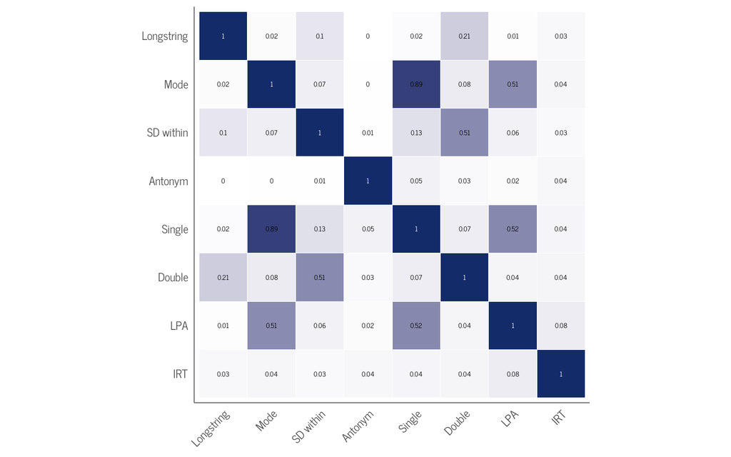

```r
jaccard_matrix <- vegan::vegdist(
  t(df_indices_models_no_rt),
  na.rm = TRUE,
  method = "jaccard",
  binary = TRUE
)
jaccard_matrix <- as.matrix(jaccard_matrix)

# convert dissimilarity to similarity
jaccard_sim_matrix <- 1-jaccard_matrix

# self-similarity
diag(jaccard_sim_matrix) <- 1

column_order <- c(
  "Longstring",
  "Mode",
  "SD within",
  "Antonym",
  # "Avg. RT",
  # "SD RT",
  "Single",
  "Double",
  "LPA",
  "IRT"
)

similarity_plot_no_rt <- jaccard_sim_matrix |>
  as.data.frame() |>
  rownames_to_column(var = "Var1") |>
  filter(!Var1 %in% c("flag_average_response_time", "flag_sd_response_time")) |>
  pivot_longer(-Var1, names_to = "Var2", values_to = "Similarity") |>
  filter(!Var2 %in% c("flag_average_response_time", "flag_sd_response_time")) |>
  mutate(
    Var1 = case_when(
      Var1 == "flag_sd_within" ~ "SD within",
      # Var1 == "flag_average_response_time" ~ "Avg. RT",
      # Var1 == "flag_sd_response_time" ~ "SD RT",
      Var1 == "flag_longstring" ~ "Longstring",
      Var1 == "flag_mode" ~ "Mode",
      Var1 == "flag_anto" ~ "Antonym",
      Var1 == "flag_lpa" ~ "LPA",
      Var1 == "flag_irt" ~ "IRT",
      Var1 == "single_hurdle" ~ "Single",
      Var1 == "double_hurdle" ~ "Double",
      TRUE ~ Var1
    ),
    Var2 = case_when(
      Var2 == "flag_sd_within" ~ "SD within",
      # Var2 == "flag_average_response_time" ~ "Avg. RT",
      # Var2 == "flag_sd_response_time" ~ "SD RT",
      Var2 == "flag_longstring" ~ "Longstring",
      Var2 == "flag_mode" ~ "Mode",
      Var2 == "flag_anto" ~ "Antonym",
      Var2 == "flag_lpa" ~ "LPA",
      Var2 == "flag_irt" ~ "IRT",
      Var2 == "single_hurdle" ~ "Single",
      Var2 == "double_hurdle" ~ "Double",
      TRUE ~ Var2
    )) |>
  mutate(
    Var1 = factor(Var1, levels = column_order),
    Var2 = factor(Var2, levels = rev(column_order)),
    text_color = if_else(Var1 == Var2, "white", "black")
  ) |>
  ggplot(aes(x = Var1, y = Var2, fill = Similarity)) +
  geom_tile(color = "white") +
  scale_fill_gradient(
    low = "white",
    high = fill_color,
    limit = c(0, 1),
    space = "Lab",
    name = "Jaccard\nSimilarity"
  ) +
  theme_bs() +
  theme(
    axis.text.x = element_text(angle = 45, vjust = 1, hjust = 1),
    axis.title.x = element_blank(),
    axis.title.y = element_blank(),
    panel.grid.major = element_blank(),
    panel.border = element_blank(),
    legend.justification = c(1, 0),
    legend.position = "none"
  ) +
  coord_fixed() +
  geom_text(aes(label = round(Similarity, 2), color = text_color), size = 3.8) +
  scale_color_identity()

similarity_plot_no_rt
```

```r
ggsave("similarity_plot_no_rt.pdf", similarity_plot_no_rt, path = here::here("figures"),
       width = 7, height = 5)
```

We create the same plot with a row indicating the mean similarity for each method:

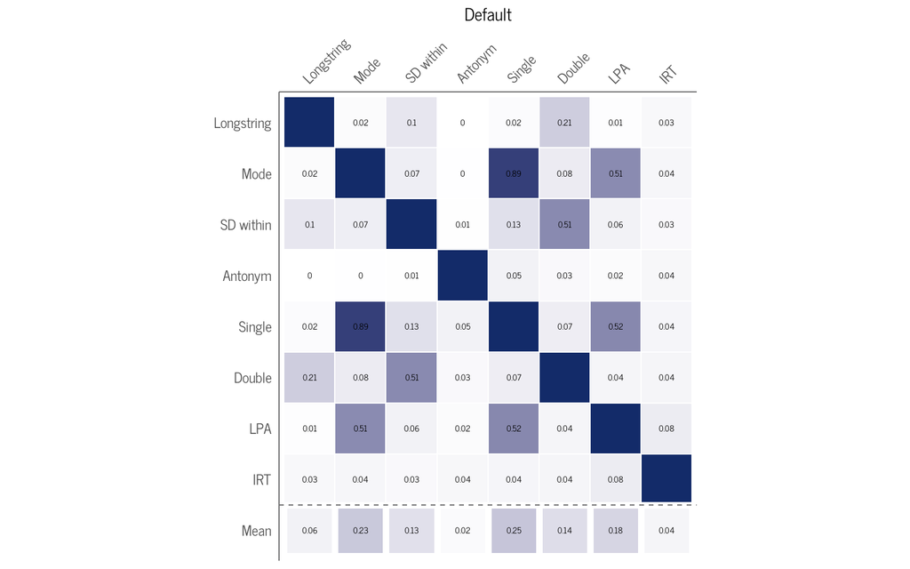

```r
# exclude reaction time indices from similarity matrix
# before computing mean
# identify indices that do not contain "response_time"
keep_indices <- grep("response_time", rownames(jaccard_sim_matrix),
                     invert = TRUE, value = FALSE)

# keep those filtered columns
filtered_matrix <- jaccard_sim_matrix[keep_indices, keep_indices]

# Calculate mean similarities (excluding diagonal)
mean_similarities <- sapply(1:ncol(filtered_matrix), function(i) {
  col_vals <- filtered_matrix[, i]
  mean(col_vals[-i])  # exclude diagonal element
})
names(mean_similarities) <- colnames(filtered_matrix)

# main similarity data
similarity_data <- filtered_matrix |>
  as.data.frame() |>
  rownames_to_column(var = "Var1") |>
  filter(!Var1 %in% c("flag_average_response_time", "flag_sd_response_time")) |>
  pivot_longer(-Var1, names_to = "Var2", values_to = "Similarity") |>
  filter(!Var2 %in% c("flag_average_response_time", "flag_sd_response_time")) |>
  mutate(
    Var1 = case_when(
      Var1 == "flag_sd_within" ~ "SD within",
      # Var1 == "flag_average_response_time" ~ "Avg. RT",
      # Var1 == "flag_sd_response_time" ~ "SD RT",
      Var1 == "flag_longstring" ~ "Longstring",
      Var1 == "flag_mode" ~ "Mode",
      Var1 == "flag_anto" ~ "Antonym",
      Var1 == "flag_lpa" ~ "LPA",
      Var1 == "flag_irt" ~ "IRT",
      Var1 == "single_hurdle" ~ "Single",
      Var1 == "double_hurdle" ~ "Double",
      TRUE ~ Var1
    ),
    Var2 = case_when(
      Var2 == "flag_sd_within" ~ "SD within",
      # Var2 == "flag_average_response_time" ~ "Avg. RT",
      # Var2 == "flag_sd_response_time" ~ "SD RT",
      Var2 == "flag_longstring" ~ "Longstring",
      Var2 == "flag_mode" ~ "Mode",
      Var2 == "flag_anto" ~ "Antonym",
      Var2 == "flag_lpa" ~ "LPA",
      Var2 == "flag_irt" ~ "IRT",
      Var2 == "single_hurdle" ~ "Single",
      Var2 == "double_hurdle" ~ "Double",
      TRUE ~ Var2
    ),
    row_type = "main"
  )

# mean row data
mean_data <- data.frame(
  Var1 = "Mean",
  Var2 = names(mean_similarities),
  Similarity = as.numeric(mean_similarities),
  row_type = "mean"
) |>
  mutate(
    Var2 = case_when(
      Var2 == "flag_sd_within" ~ "SD within",
      # Var2 == "flag_average_response_time" ~ "Avg. RT",
      # Var2 == "flag_sd_response_time" ~ "SD RT",
      Var2 == "flag_longstring" ~ "Longstring",
      Var2 == "flag_mode" ~ "Mode",
      Var2 == "flag_anto" ~ "Antonym",
      Var2 == "flag_lpa" ~ "LPA",
      Var2 == "flag_irt" ~ "IRT",
      Var2 == "single_hurdle" ~ "Single",
      Var2 == "double_hurdle" ~ "Double",
      TRUE ~ Var2
    )
  )

# combine data
combined_data <- rbind(similarity_data, mean_data) |>
  mutate(
    text_color = case_when(
      row_type == "mean" ~ "black",
      Var1 == Var2 ~ fill_color,
      TRUE ~ "black"
    ),
    Var1 = factor(Var1, levels = c("Mean", rev(column_order))),
    Var2 = factor(Var2, levels = column_order)
  )


similarity_plot_mean_no_rt <- combined_data |>
  ggplot(aes(x = Var2, y = Var1, fill = Similarity)) +
  geom_tile(color = "white", size = ifelse(combined_data$row_type == "mean", 2, 0.5)) +
  # Add a thicker separator line above the mean row
  geom_hline(yintercept = 1.5, color = "#6d6d6e", linewidth = .5, linetype = 2) +
  scale_fill_gradient(
    low = "white",
    high = fill_color,
    limit = c(0, 1),
    space = "Lab",
    name = "Jaccard\nSimilarity"
  ) +
  theme_bs() +
  theme(
    axis.text.x = element_text(angle = 45, vjust = 0, hjust = 0),
    axis.title.x = element_blank(),
    axis.title.y = element_blank(),
    panel.grid.major = element_blank(),
    panel.border = element_blank(),
    legend.justification = c(1, 0),
    legend.position = "none",
    axis.text.x.top = element_text(angle = 45, vjust = 0, hjust = 0),
    axis.text.x.bottom = element_blank(),
    plot.margin = margin(t = 5,r = 1,b = 5,l = 1)
  ) +
  scale_x_discrete(position = "top") +
  coord_fixed() +
  geom_text(aes(label = round(Similarity, 2), color = text_color), size = 3.8) +
  scale_color_identity()+
  labs(title = "Default")

similarity_plot_mean_no_rt
```

```r
ggsave("similarity_plot_mean_no_rt.pdf", similarity_plot_mean_no_rt, path = here::here("figures"),
       width = 7, height = 5)
```

### 3.1.2 Lenient/Sensitivity Specification

Instead of using the main specification, we can use the most lenient one here:

```r
df_indices_models_lenient_no_rt <- lpa_res_no_rt |>
  left_join(irt_res, by = c("external_id", "counter")) |>
  left_join(lenient_flag_df_no_rt, by = c("external_id", "counter")) |>
    mutate(across(where(is.logical), ~ as.integer(.))) |>
    mutate(flag_lpa = ifelse(LPA_profile != 2, 1, 0),
           flag_irt = ifelse(mixtureIRT == 1, 0, 1)) |>
   select(contains("flag")) |>
  # recode to obtain single hurdle and multiple hurdle approach
  mutate(
    single_hurdle = if_else(flag_sum == 0, 0, 1),
    double_hurdle = if_else(flag_sum < 2, 0, 1)
  ) |>
  # then remove raw sum
  select(!flag_sum)
```

We then re-create the Jaccard similarity plot:

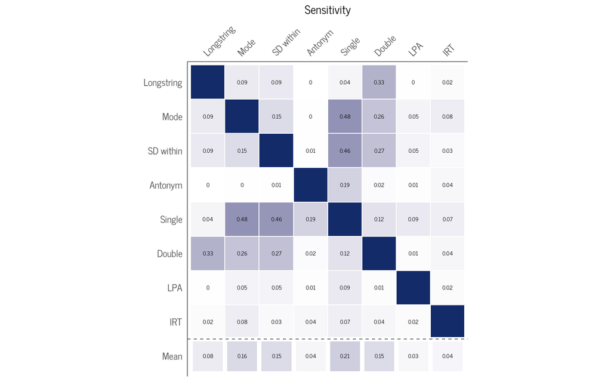

```r
jaccard_matrix <- vegan::vegdist(
  t(df_indices_models_lenient_no_rt),
  na.rm = TRUE,
  method = "jaccard",
  binary = TRUE
)
jaccard_matrix <- as.matrix(jaccard_matrix)

# convert dissimilarity to similarity
jaccard_sim_matrix <- 1-jaccard_matrix

# self-similarity
diag(jaccard_sim_matrix) <- 1

column_order <- c(
  "Longstring",
  "Mode",
  "SD within",
  "Antonym",
  # "Avg. RT",
  # "SD RT",
  "Single",
  "Double",
  "LPA",
  "IRT"
)


# exclude reaction time indices from similarity matrix
# before computing mean
# identify indices that do not contain "response_time"
keep_indices <- grep("response_time", rownames(jaccard_sim_matrix),
                     invert = TRUE, value = FALSE)

# keep those filtered columns
filtered_matrix <- jaccard_sim_matrix[keep_indices, keep_indices]

# Calculate mean similarities (excluding diagonal)
mean_similarities <- sapply(1:ncol(filtered_matrix), function(i) {
  col_vals <- filtered_matrix[, i]
  mean(col_vals[-i])  # exclude diagonal element
})
names(mean_similarities) <- colnames(filtered_matrix)



# main similarity data
similarity_data <- jaccard_sim_matrix |>
  as.data.frame() |>
  rownames_to_column(var = "Var1") |>
  filter(!Var1 %in% c("flag_average_response_time", "flag_sd_response_time")) |>
  pivot_longer(-Var1, names_to = "Var2", values_to = "Similarity") |>
  filter(!Var2 %in% c("flag_average_response_time", "flag_sd_response_time")) |>
  mutate(
    Var1 = case_when(
      Var1 == "flag_sd_within" ~ "SD within",
      # Var1 == "flag_average_response_time" ~ "Avg. RT",
      # Var1 == "flag_sd_response_time" ~ "SD RT",
      Var1 == "flag_longstring" ~ "Longstring",
      Var1 == "flag_mode" ~ "Mode",
      Var1 == "flag_anto" ~ "Antonym",
      Var1 == "flag_lpa" ~ "LPA",
      Var1 == "flag_irt" ~ "IRT",
      Var1 == "single_hurdle" ~ "Single",
      Var1 == "double_hurdle" ~ "Double",
      TRUE ~ Var1
    ),
    Var2 = case_when(
      Var2 == "flag_sd_within" ~ "SD within",
      # Var2 == "flag_average_response_time" ~ "Avg. RT",
      # Var2 == "flag_sd_response_time" ~ "SD RT",
      Var2 == "flag_longstring" ~ "Longstring",
      Var2 == "flag_mode" ~ "Mode",
      Var2 == "flag_anto" ~ "Antonym",
      Var2 == "flag_lpa" ~ "LPA",
      Var2 == "flag_irt" ~ "IRT",
      Var2 == "single_hurdle" ~ "Single",
      Var2 == "double_hurdle" ~ "Double",
      TRUE ~ Var2
    ),
    row_type = "main"
  )

# mean row data
mean_data <- data.frame(
  Var1 = "Mean",
  Var2 = names(mean_similarities),
  Similarity = as.numeric(mean_similarities),
  row_type = "mean"
) |>
  mutate(
    Var2 = case_when(
      Var2 == "flag_sd_within" ~ "SD within",
      # Var2 == "flag_average_response_time" ~ "Avg. RT",
      # Var2 == "flag_sd_response_time" ~ "SD RT",
      Var2 == "flag_longstring" ~ "Longstring",
      Var2 == "flag_mode" ~ "Mode",
      Var2 == "flag_anto" ~ "Antonym",
      Var2 == "flag_lpa" ~ "LPA",
      Var2 == "flag_irt" ~ "IRT",
      Var2 == "single_hurdle" ~ "Single",
      Var2 == "double_hurdle" ~ "Double",
      TRUE ~ Var2
    )
  )

# combine data
combined_data <- rbind(similarity_data, mean_data) |>
  mutate(
    text_color = case_when(
      row_type == "mean" ~ "black",
      Var1 == Var2 ~ fill_color,
      TRUE ~ "black"
    ),
    Var1 = factor(Var1, levels = c("Mean", rev(column_order))),
    Var2 = factor(Var2, levels = column_order)
  )


similarity_plot_mean_lenient_no_rt <- combined_data |>
  ggplot(aes(x = Var2, y = Var1, fill = Similarity)) +
  geom_tile(color = "white", size = ifelse(combined_data$row_type == "mean", 2, 0.5)) +
  # Add a thicker separator line above the mean row
  geom_hline(yintercept = 1.5, color = "#6d6d6e", linewidth = .5, linetype = 2) +
  scale_fill_gradient(
    low = "white",
    high = fill_color,
    limit = c(0, 1),
    space = "Lab",
    name = "Jaccard\nSimilarity"
  ) +
  theme_bs() +
  theme(
    axis.text.x = element_text(angle = 45, vjust = 0, hjust = 0),
    axis.title.x = element_blank(),
    axis.title.y = element_blank(),
    panel.grid.major = element_blank(),
    panel.border = element_blank(),
    legend.justification = c(1, 0),
    legend.position = "none",
    axis.text.x.top = element_text(angle = 45, vjust = 0, hjust = 0),
    axis.text.x.bottom = element_blank(),
    plot.margin = margin(t = 5,r = 1,b = 5,l = 1)
  ) +
  scale_x_discrete(position = "top") +
  coord_fixed() +
  geom_text(aes(label = round(Similarity, 2), color = text_color), size = 3.8) +
  scale_color_identity()+
  labs(title = "Sensitivity")

similarity_plot_mean_lenient_no_rt
```

```r
ggsave(
  "similarity_plot_mean_lenient_no_rt.pdf",
  similarity_plot_mean_lenient_no_rt,
  path = here::here("figures"),
  width = 7,
  height = 5
)
```

### 3.1.3 Combine Specification Plots

We combine both Jaccard similarity mean plots in one plot:

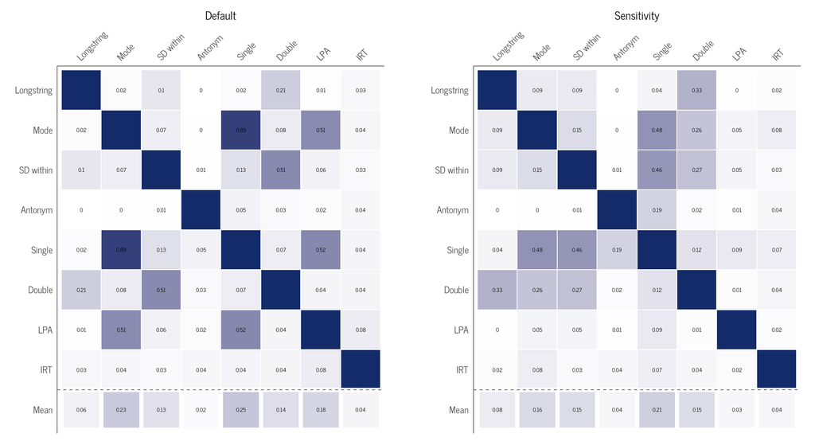

```r
jaccard_plot_combined_no_rt <- similarity_plot_mean_no_rt + plot_spacer() +  similarity_plot_mean_lenient_no_rt + plot_layout(ncol = 3, widths = c(1, 0.05, 1))

ggsave(
  "jaccard_plot_combined_no_rt.pdf",
  jaccard_plot_combined_no_rt,
  path = here::here("figures"),
  width = 11,
  height = 6
)

jaccard_plot_combined_no_rt
```

**R version 4.5.1 (2025-06-13 ucrt)**

**Platform:** x86_64-w64-mingw32/x64

**locale:** *LC_COLLATE=German_Germany.utf8*, *LC_CTYPE=German_Germany.utf8*, *LC_MONETARY=German_Germany.utf8*, *LC_NUMERIC=C* and *LC_TIME=German_Germany.utf8*

**attached base packages:** *stats*, *graphics*, *grDevices*, *utils*, *datasets*, *methods* and *base*

**other attached packages:** *patchwork(v.1.3.0)*, *flextable(v.0.9.7)*, *purrr(v.1.0.4)*, *tibble(v.3.3.0)*, *vegan(v.2.6-10)*, *lattice(v.0.22-7)*, *permute(v.0.9-7)*, *tidyr(v.1.3.1)*, *dplyr(v.1.1.4)*, *furrr(v.0.3.1)*, *future(v.1.40.0)*, *gt(v.1.0.0)*, *gtsummary(v.2.2.0)*, *cowplot(v.1.1.3)*, *ggh4x(v.0.3.0)*, *showtext(v.0.9-7)*, *showtextdb(v.3.0)*, *sysfonts(v.0.8.9)*, *Hmisc(v.5.2-3)*, *rrcov(v.1.7-7)*, *robustbase(v.0.99-4-1)*, *ggplot2(v.3.5.2.9001)*, *here(v.1.0.1)* and *pacman(v.0.5.1)*

**loaded via a namespace (and not attached):** *tidyselect(v.1.2.1)*, *farver(v.2.1.2)*, *S7(v.0.2.0)*, *fastmap(v.1.2.0)*, *fontquiver(v.0.2.1)*, *digest(v.0.6.37)*, *rpart(v.4.1.24)*, *lifecycle(v.1.0.4)*, *cluster(v.2.1.8.1)*, *magrittr(v.2.0.3)*, *compiler(v.4.5.1)*, *rlang(v.1.1.6)*, *tools(v.4.5.1)*, *yaml(v.2.3.10)*, *data.table(v.1.17.0)*, *knitr(v.1.50)*, *labeling(v.0.4.3)*, *askpass(v.1.2.1)*, *htmlwidgets(v.1.6.4)*, *curl(v.6.2.2)*, *xml2(v.1.4.0)*, *RColorBrewer(v.1.1-3)*, *withr(v.3.0.2)*, *foreign(v.0.8-90)*, *nnet(v.7.3-20)*, *grid(v.4.5.1)*, *pcaPP(v.2.0-5)*, *stats4(v.4.5.1)*, *gdtools(v.0.4.2)*, *colorspace(v.2.1-1)*, *globals(v.0.17.0)*, *scales(v.1.4.0)*, *MASS(v.7.3-65)*, *cli(v.3.6.5)*, *mvtnorm(v.1.3-3)*, *rmarkdown(v.2.29)*, *ragg(v.1.4.0)*, *generics(v.0.1.3)*, *rstudioapi(v.0.17.1)*, *pander(v.0.6.6)*, *stringr(v.1.5.1)*, *splines(v.4.5.1)*, *parallel(v.4.5.1)*, *base64enc(v.0.1-3)*, *vctrs(v.0.6.5)*, *Matrix(v.1.7-3)*, *jsonlite(v.2.0.0)*, *fontBitstreamVera(v.0.1.1)*, *Formula(v.1.2-5)*, *htmlTable(v.2.4.3)*, *listenv(v.0.9.1)*, *systemfonts(v.1.2.3)*, *glue(v.1.8.0)*, *parallelly(v.1.43.0)*, *DEoptimR(v.1.1-3-1)*, *codetools(v.0.2-20)*, *stringi(v.1.8.7)*, *gtable(v.0.3.6)*, *pillar(v.1.11.0)*, *htmltools(v.0.5.8.1)*, *openssl(v.2.3.3)*, *R6(v.2.6.1)*, *textshaping(v.1.0.0)*, *rprojroot(v.2.0.4)*, *evaluate(v.1.0.3)*, *backports(v.1.5.0)*, *fontLiberation(v.0.1.0)*, *zip(v.2.3.2)*, *uuid(v.1.2-1)*, *Rcpp(v.1.0.14)*, *gridExtra(v.2.3)*, *nlme(v.3.1-168)*, *checkmate(v.2.3.2)*, *mgcv(v.1.9-3)*, *officer(v.0.6.8)*, *xfun(v.0.52)*, *forcats(v.1.0.0)* and *pkgconfig(v.2.0.3)*